## Tornadoes Threaten Population Health

#### Synopsis

What follows is a technical document describing the analysis of a large data set from the National Climatic Data Center.

#### Data Processing

The extreme weather dataset available from the National Climatic Data Center comes in the form of a large “.bz2” file. Using the software R, it is efficient to read the first five rows of the data table, determine whether the columns are “character” or “numeric” vectors, and then read the whole dataset with the column classes specified.

```r
if(!file.exists("./data")) dir.create("./data")
if(!file.exists("./data/stormdata.csv.bz2")) {
fileUrl = "https://d396qusza40orc.cloudfront.net/repdata%2Fdata%2FStormData.csv.bz2"
download.file(fileUrl, destfile = "./data/stormdata.csv.bz2")
}
if(!exists("DF")) {
tab5rows <- read.csv(bzfile("./data/stormdata.csv.bz2"), header = T, nrows = 5,
                     stringsAsFactors = F)
classes <- sapply(tab5rows, class)
classes <- sub("integer", "character", classes) ## These may not really be integers
classes <- sub("logical", "character", classes) ## These may not really be logical values
df <- read.csv(bzfile("./data/stormdata.csv.bz2"), header = T, colClasses = classes,
               comment.char = "", nrows = 910000) ## This could take a while...
}
```

The “EVTYPE” variable gives a basic description for every extreme weather events. In the early years of the NCDC storm database, the “EVTYPE” variable was not coded carefully: there was typos and inconsistent labelling. The coding became much cleaner over time.

```r
## Get EVTYPE values since the first catalogued storm event in 1950
levels(factor(df$EVTYPE))[1:20]
```

```
##  [1] "   HIGH SURF ADVISORY"  " COASTAL FLOOD"
##  [3] " FLASH FLOOD"           " LIGHTNING"
##  [5] " TSTM WIND"             " TSTM WIND (G45)"
##  [7] " WATERSPOUT"            " WIND"
##  [9] "?"                      "ABNORMAL WARMTH"
## [11] "ABNORMALLY DRY"         "ABNORMALLY WET"
## [13] "ACCUMULATED SNOWFALL"   "AGRICULTURAL FREEZE"
## [15] "APACHE COUNTY"          "ASTRONOMICAL HIGH TIDE"
## [17] "ASTRONOMICAL LOW TIDE"  "AVALANCE"
## [19] "AVALANCHE"              "BEACH EROSIN"
```

```r
## Get EVTYPE values since 2000
df$BGN_DATE <- as.Date(df$BGN_DATE, format = "%m/%d/%Y")
df <- df[df$BGN_DATE >= "2000-1-01", ]
levels(factor(df$EVTYPE))[1:20]
```

```
##  [1] "   HIGH SURF ADVISORY"        " FLASH FLOOD"
##  [3] " TSTM WIND"                   " WATERSPOUT"
##  [5] "ABNORMALLY DRY"               "ABNORMALLY WET"
##  [7] "ACCUMULATED SNOWFALL"         "ASTRONOMICAL HIGH TIDE"
##  [9] "ASTRONOMICAL LOW TIDE"        "AVALANCHE"
## [11] "BEACH EROSION"                "BLACK ICE"
## [13] "BLIZZARD"                     "BLOWING DUST"
## [15] "BRUSH FIRE"                   "COASTAL FLOOD"
## [17] "COASTAL FLOODING"             "COLD"
## [19] "COLD WEATHER"                 "COLD WIND CHILL TEMPERATURES"
```

By December 1st, 2006, the National Weather Service and the National Climatic Data Center were using 48 official “EVTYPE” designations for extreme weather events.

```r
## Get EVTYPE values since 12/1/2006
df <- df[df$BGN_DATE >= "2006-12-01", ]
df$EVTYPE <- factor(df$EVTYPE)
levels(df$EVTYPE)[1:20]
```

```
##  [1] "ASTRONOMICAL LOW TIDE"   "AVALANCHE"
##  [3] "BLIZZARD"                "COASTAL FLOOD"
##  [5] "COLD/WIND CHILL"         "DENSE FOG"
##  [7] "DENSE SMOKE"             "DROUGHT"
##  [9] "DUST DEVIL"              "DUST STORM"
## [11] "EXCESSIVE HEAT"          "EXTREME COLD/WIND CHILL"
## [13] "FLASH FLOOD"             "FLOOD"
## [15] "FREEZING FOG"            "FROST/FREEZE"
## [17] "FUNNEL CLOUD"            "HAIL"
## [19] "HEAT"                    "HEAVY RAIN"
```

We have clipped the data at December 1st, 2006. It is important to explain why we have done so.

- After 12/1/2006, the data appears to be coded carefully, according to rigorous standards. Before this time, the data is of variable quality. The older the data, the greater the possibility of corruption. Corrupt data could skew an analysis and paint a false picture of extreme weather in America. Separating the “true” data from the “corrupt” data is theoretically possible, but it is beyond the scope of this analysis.
- We could potentially clip the data two months earlier. Starting on 10/1/2006, the NWS and NCDC fully implemented the use of 48 official “EVTYPE” values. By clipping the data on 12/1/2006, however, we get an even five years of records, from 12/1/2006 to 11/30/2011. This makes the interpretation of data simple. In particular, we can divide by five to get yearly averages.
- Old data is hard to interpret. A tornado or thunderstorm occuring today might cause more damage than it would have caused in 1990 because of population growth and urbanization in America. The inflation of the American dollar makes it difficult to compare property damage when storms are separated by long intervals of time. There is also evidence that global warming (“global weirding”) is increasing the frequency of natural disasters. For these reasons, it is better to look at more recent data, so we get an accurate picture of the frequency and severity of weather events today.
- By clipping the data at 12/1/2006, we could be ignoring potentially useful data. There may be certain types of storms that occur rarely but exact a huge toll in human casualties and property damage. These storms may be conspicuously absent in our clipped analysis. We must accept that the data are not perfect, but clipping the data at 12/1/2006 is the best strategy available to us.

Before we calculate results, we have to perform some minor cleaning of the property damage variable.

```r
df$PROPDMGEXP <- sub("0", "1", df$PROPDMGEXP)
df$PROPDMGEXP <- sub("K", "1000", df$PROPDMGEXP)
df$PROPDMGEXP <- sub("M", "1000000", df$PROPDMGEXP)
df$PROPDMGEXP <- sub("B", "1000000000", df$PROPDMGEXP)
df$PROPDMGEXP <- as.numeric(df$PROPDMGEXP)
df$PROPDMG <- df$PROPDMG * df$PROPDMGEXP
```

#### Results

Let’s calculate the top ten causes of injuries and the top ten causes of fatalities due to extreme weather in America.

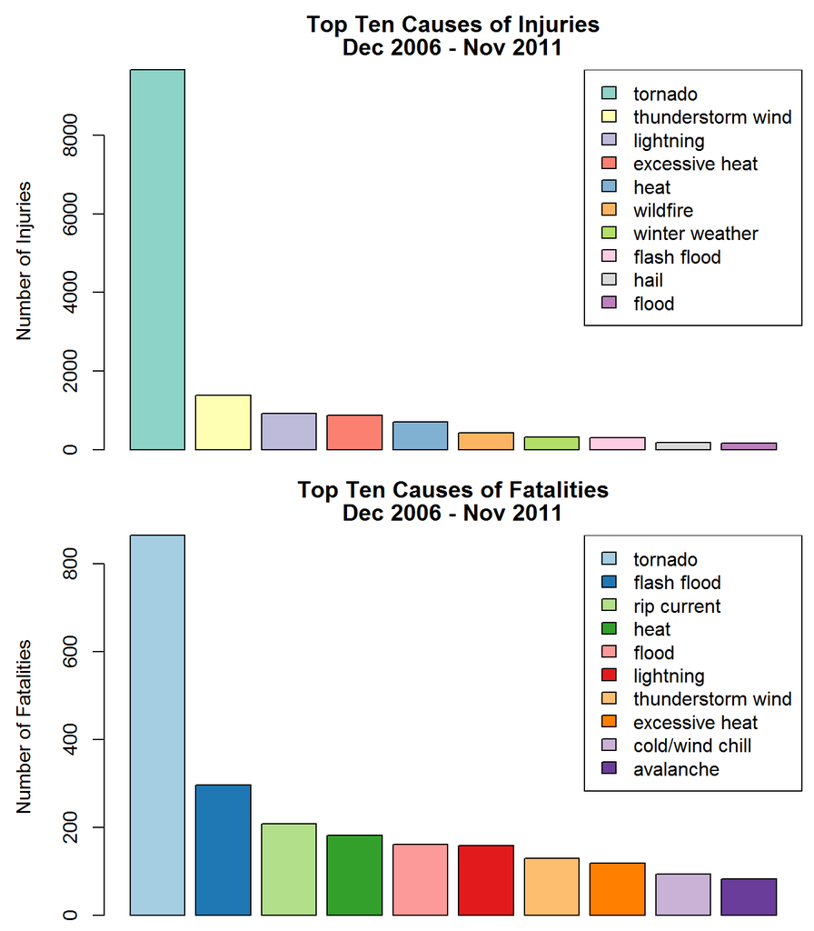

```r
df$EVTYPE <- tolower(df$EVTYPE) ## for easier reading
library(reshape2)
dfmelt <- melt(df, id.vars = "EVTYPE", measure.vars = c("FATALITIES", "INJURIES"))
sumdf <- dcast(dfmelt, EVTYPE ~ variable, sum)
top10inj <- sumdf[order(sumdf$INJURIES, decreasing = T), ][1:10, ]
top10fat <- sumdf[order(sumdf$FATALITIES, decreasing = T), ][1:10, ]

## Default colors in R are ugly. RColorBrewer does a better job.
par(mfcol = c(2, 1), mar = c(0.5, 4.5, 3, 0.5))
library(RColorBrewer)
cols2 <- brewer.pal(10, "Set3")
barplot(top10inj$INJURIES, col = cols2, ylab = "Number of Injuries",
        main =c("Top Ten Causes of Injuries", "Dec 2006 - Nov 2011"))
legend("topright", legend = top10inj$EVTYPE, fill = cols2)
cols <- brewer.pal(10, "Paired")
barplot(top10fat$FATALITIES, col = cols, ylab = "Number of Fatalities",
        main = c("Top Ten Causes of Fatalities", "Dec 2006 - Nov 2011"))
legend("topright", legend = top10fat$EVTYPE, fill = cols)
```

Tornadoes are far and away the greatest threat to population health in America. From December 2006 to November 2011, tornados caused 9661 injuries and 864 fatalities. Thunderstorm wind, lightning, and heat-related events are among the next leading causes of injuries and fatalities.

Next, let’s calculate the top ten causes of property damage due to extreme weather events.

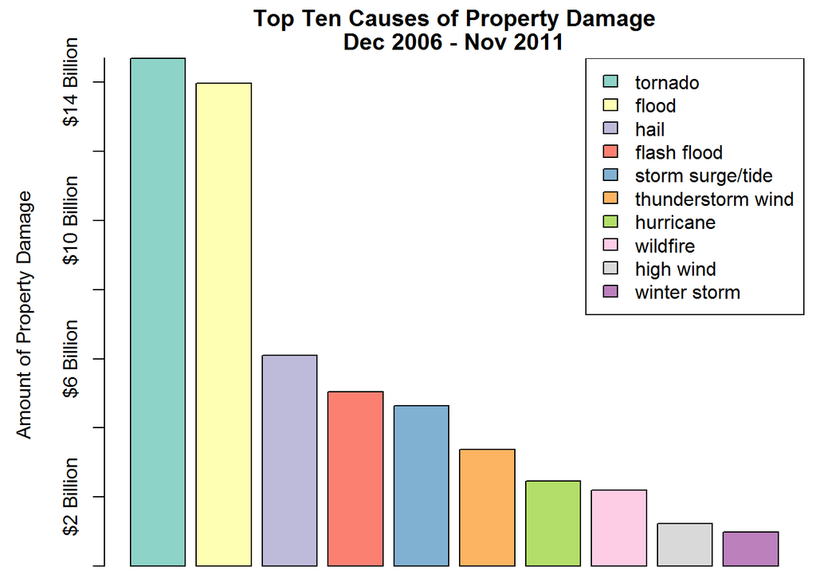

```r
## I like the power and control of the "reshape2" package, as opposed to "aggregate"
dfmelt <- melt(df, id.vars = "EVTYPE", measure.vars = "PROPDMG")
sumdf <- dcast(dfmelt, EVTYPE ~ variable, sum)
top10prop <- sumdf[order(sumdf$PROPDMG, decreasing = T), ][1:10, ]

par(mfcol = c(1, 1), mar = c(0.5, 4.5, 2.5, 0.5))
barplot(top10prop$PROPDMG, col = cols2, axes = F, ylab = "Amount of Property Damage",
        main = c("Top Ten Causes of Property Damage", "Dec 2006 - Nov 2011"))
legend("topright", legend = top10prop$EVTYPE, fill = cols2)
axis(2, at = c(0, seq(2000000000, 16000000000, by = 2000000000)),
     labels = c("", "$2 Billion", "", "$6 Billion", "", "$10 Billion", "",
                "$14 Billion", ""))
```

#### Conclusion

This analysis provides a good introduction to the weather events that are most harmful in America. Nation-wide, policymakers should prioritize preparation for tornadoes and flood-related events above other natural disasters. However, tornadoes and flood are concentrated in specific regions of the United States. It is unusual to hear of a tornado in Louisiana or a flood in Wyoming. Policymakers should therefore prepare for national disasters locally; they should consider what events are the most harmful in a particular region and prepare for those events.

This analysis yields different results, depending whether policymakers are interested in population health or property damage. In terms of population health, tornadoes are the most harmful extreme weather event. In terms of property damage, tornadoes are rivaled by flooding.

The results of this analysis are shaped by the precise definitions of the “EVTYPE” variables. “flood”, “flash flood”, and “storm surge/tide” are all analyzed individually, yet these are related events. In the future, “EVTYPE” categories should be redefined depending on the reason for the analysis and the particular questions being asked.